# TTRw and altitude (folklore texts)

#Interpolation of Heap’s curves with zipfR

```r
languages = c('agx', 'ava', 'kum', 'rut', 'dar', 'tab', 'lak', 'lez', 'nog', 'tkr', 'arch', 'khv')
```

## observed values

Vocabulary growth curve (VGC) reports vocabulary size (number of types, V ) as a function of sample size (number of tokens, N)

```r
for (language in languages) {

  type_count <- read.vgc(paste0("type_counts_texts/", language, "-folk_type_counts.txt"))
  var_name1 <- paste0("type_count_", language)
  assign(var_name1, type_count)
}
```

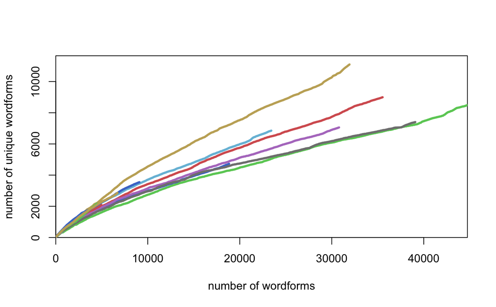

```r
plot(type_count_agx,
     type_count_ava,
     type_count_kum,
     type_count_rut,
     type_count_dar,
     type_count_tab,
     type_count_lak,
     type_count_lez,
     type_count_nog,
     type_count_tkr,
     type_count_arch,
     type_count_khv,
     xlab = "number of wordforms", ylab = "number of unique wordforms", main = ""
     )
```

## expected values

`vgc.interp` computes the expected vocabulary growth curve In addition, we extract the TTR value from the expected curve at the particular corpus size and save it to csv

```r
ttr_at_particular_corpus_size <- data.frame(languages)

for (language in languages) {

  freq_list <- read.tfl(paste0("frequency_lists_texts/", language, "-folk_freq.txt"))
  freq_spectrum <- tfl2spc(freq_list)
  type_count <- read.vgc(paste0("type_counts_texts/", language, "-folk_type_counts.txt"))

  interpolated_type_count <- vgc.interp(freq_spectrum, N(type_count))



 #for checking correlations at different corpus sizes
  ttr_for_one_language <- c()
  x <- 4000 # the corpus size where we take TTR values
  n_of_types <- interpolated_type_count$V[interpolated_type_count$N == x]
  ttr_for_one_language <- n_of_types/x

  ttr_at_particular_corpus_size$value[ttr_at_particular_corpus_size$lang == language] <- ttr_for_one_language


  var_name1 <- paste0("interpolated_type_count_", language)
  assign(var_name1, interpolated_type_count)

}
```

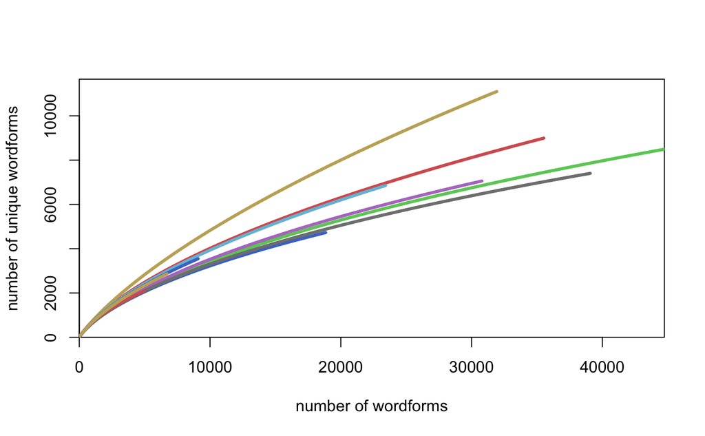

```r
plot(interpolated_type_count_agx,
     interpolated_type_count_ava,
     interpolated_type_count_kum,
     interpolated_type_count_rut,
     interpolated_type_count_dar,
     interpolated_type_count_tab,
     interpolated_type_count_lak,
     interpolated_type_count_lez,
     interpolated_type_count_nog,
     interpolated_type_count_tkr,
     interpolated_type_count_arch,
     interpolated_type_count_khv,
     xlab = "number of wordforms", ylab = "number of unique wordforms", main = ""


     )
```

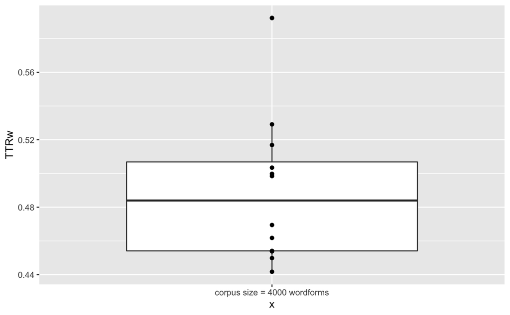

```r
p <- ggplot(ttr_at_particular_corpus_size, aes(y=value, x = "corpus size = 4000 wordforms")) +
  geom_boxplot() +
  geom_jitter(width = 0) +
  labs(y = "TTRw")
p
```

```r
colnames(ttr_at_particular_corpus_size)[1] <- "iso_lang"
write.csv(ttr_at_particular_corpus_size,"ttr_at_particular_corpus_size_folk.csv", row.names = FALSE)
ttr_at_particular_corpus_size -> ttr2
```

# Altitude (median)

```r
alt <- read.csv("villages_Lesha_K.csv",
                header = TRUE, sep = "\t")
alt %>%
  select("lang", "gltc_lang", "elevation", "aff") -> alt2
alt2
```

| lang | gltc_lang | elevation | aff |
| --- | --- | --- | --- |
| Avar | avar1256 | 288.909058 | Avar |
| Avar | avar1256 | 21.714314 | Avar |
| Chechen | chec1245 | 1607.911865 | Nakh |
| Chechen | chec1245 | 486.578613 | Nakh |
| Chechen | chec1245 | 248.783295 | Nakh |
| Dargwa | darg1241 | 1109.091553 | Dargwa |
| Kumyk | kumy1244 | 297.048889 | Kipchak |
| Kumyk | kumy1244 | 6.263140 | Kipchak |
| Chechen | chec1245 | 10.997546 | Nakh |
| Dargwa | darg1241 | 1446.875122 | Dargwa |

[output cut: 990 more lines]

```r
alt2 %>%
  filter(alt2$elevation != "NA") %>%
  group_by(gltc_lang) %>%
  summarise(alt_median = median (elevation), n_villages = n()) -> altitude_medians
altitude_medians %>%
  mutate(iso_lang = iso.gltc(gltc_lang)) -> altitude_medians2
altitude_medians2
```

| gltc_lang | alt_median | n_villages | iso_lang |
| --- | --- | --- | --- |
| aghu1253 | 1964.591187 | 21 | agx |
| akhv1239 | 1566.518311 | 11 | akv |
| andi1255 | 1573.820923 | 17 | ani |
| arch1244 | 2117.404053 | 7 | aqc |
| avar1256 | 1281.305664 | 526 | ava |
| bagv1239 | 1667.692871 | 7 | kva |
| bats1242 | 470.884552 | 1 | bbl |
| bezh1248 | 927.854050 | 6 | kap |
| botl1242 | 956.206177 | 3 | bph |
| budu1248 | 1785.722656 | 1 | bdk |

[output cut: 23 more lines]

restore affiliation

```r
alt %>%
  select ("aff", "gltc_lang") %>%
  distinct()  -> aff_df
merge (altitude_medians2, aff_df) -> altitude_medians2_with_aff
altitude_medians2_with_aff
```

| gltc_lang | alt_median | n_villages | iso_lang | aff |
| --- | --- | --- | --- | --- |
| aghu1253 | 1964.591187 | 21 | agx | Lezgic |
| akhv1239 | 1566.518311 | 11 | akv | Andic |
| andi1255 | 1573.820923 | 17 | ani | Andic |
| arch1244 | 2117.404053 | 7 | aqc | Lezgic |
| avar1256 | 1281.305664 | 526 | ava | Avar |
| bagv1239 | 1667.692871 | 7 | kva | Andic |
| bats1242 | 470.884552 | 1 | bbl | Nakh |
| bezh1248 | 927.854050 | 6 | kap | Tsezic |
| botl1242 | 956.206177 | 3 | bph | Andic |
| budu1248 | 1785.722656 | 1 | bdk | Lezgic |

[output cut: 23 more lines]

# Altitude (weighted mean)

We calculate altitude as a weighted arithmetic mean taking into account how many speakers of the given language live in the villages located at different altitudes.

```r
census <- read.csv("altitude_dagestan.csv",
                header = TRUE)

census %>%
  select("eng_vil_name", "lang_1_S", "census_2010", "elevation") -> census2

census3 <- census2[complete.cases(census2), ] #remove rows if they have missing values
census3
```

```r
census3 %>%
  group_by(lang_1_S) %>%
  summarise(lang_population_size = sum (census_2010), spoken_in_villages = n()) -> lang_population_sizes
census4 <- merge(census3, lang_population_sizes)
census4 %>%
  mutate(part_of_lang_population_size = census_2010/lang_population_size) -> census5
census5
```

assign weighted mean elevation to each language

```r
census5 %>%
  select (lang_1_S) %>%
  unique() -> weighted_alt
```

```r
for (language in unique(weighted_alt$lang_1_S)){
  #print(language)
  census5 %>%
    filter(lang_1_S == language) -> census6
  #villages_sample <- sample(census6$eng_vil_name, size = 10, replace = TRUE,
  #       prob = census6$part_of_lang_population_size)
  weighted_arithm_mean <- (sum(census6$elevation * census6$census_2010))/unique(census6$lang_population_size)

  #print(weighted_arithm_means)
  weighted_alt$weighted_altitude[weighted_alt$lang_1_S == language] <- weighted_arithm_mean

}
weighted_alt
```

restore affiliation

```r
alt %>%
  select ("aff", "lang") %>%
  distinct()  -> aff_df
colnames(weighted_alt)[1] <- "lang"
merge (weighted_alt, aff_df) -> weighted_alt_with_aff
weighted_alt_with_aff
```

| lang | weighted_altitude | aff |
| --- | --- | --- |
| Akhvakh | 1634.2786 | Andic |
| Andi | 1354.3626 | Andic |
| Archi | 2137.5552 | Lezgic |
| Avar | 766.5378 | Avar |
| Bagvalal | 1538.6104 | Andic |
| Bezhta | 1226.0808 | Tsezic |
| Botlikh | 944.8238 | Andic |
| Chamalal | 758.9604 | Andic |
| Chechen | 402.6280 | Nakh |
| Dargwa | 1012.3251 | Dargwa |

[output cut: 12 more lines]

# Merging two datasets and checking the correlation

```r
ttr2["iso_lang"][ttr2["iso_lang"] == "arch"] <- "aqc"
ttr2["iso_lang"][ttr2["iso_lang"] == "lak"] <- "lbe"
ttr2["iso_lang"][ttr2["iso_lang"] == "and"] <- "ani"
ttr2 %>%
  mutate(lang = lang.iso(iso_lang)) -> ttr2
ttr2
```

| iso_lang | value | lang |
| --- | --- | --- |
| agx | 0.4618801 | Aghul |
| ava | 0.5290907 | Avar |
| kum | 0.4538658 | Kumyk |
| rut | 0.4418199 | Rutul |
| dar | 0.5921301 | North-Central Dargwa |
| tab | 0.5169807 | Tabasaran |
| lbe | 0.4693695 | Lak |
| lez | 0.4498751 | Lezgian |
| nog | 0.4541848 | Nogai |
| tkr | 0.4997710 | Tsakhur |

[output cut: 2 more lines]

## TTR and median altitute

```r
merge(ttr2, altitude_medians2_with_aff) -> full_dat2
full_dat2
```

| iso_lang | value | lang | gltc_lang | alt_median | n_villages | aff |
| --- | --- | --- | --- | --- | --- | --- |
| agx | 0.4618801 | Aghul | aghu1253 | 1964.591187 | 21 | Lezgic |
| aqc | 0.5034672 | Archi | arch1244 | 2117.404053 | 7 | Lezgic |
| ava | 0.5290907 | Avar | avar1256 | 1281.305664 | 526 | Avar |
| dar | 0.5921301 | North-Central Dargwa | darg1241 | 1319.170288 | 291 | Dargwa |
| khv | 0.4985787 | Khwarshi-Inkhoqwari | khva1239 | 1786.679626 | 6 | Tsezic |
| kum | 0.4538658 | Kumyk | kumy1244 | 196.865372 | 58 | Kipchak |
| lbe | 0.4693695 | Lak | lakk1252 | 1667.178711 | 74 | Lak |
| lez | 0.4498751 | Lezgian | lezg1247 | 781.951782 | 145 | Lezgic |
| nog | 0.4541848 | Nogai | noga1249 | -8.321217 | 31 | Kipchak |
| rut | 0.4418199 | Rutul | rutu1240 | 1590.794189 | 17 | Lezgic |

[output cut: 2 more lines]

boxplots (make no sense because there is only one observation per language), color = branch

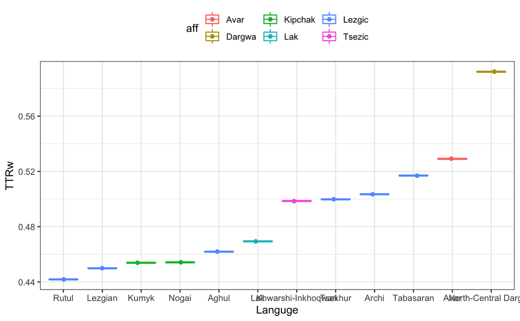

```r
full_dat2  %>%
  ggplot(aes(reorder(lang, value, FUN = median), value, color = aff))+
  geom_boxplot(outlier.shape = NA)+
  geom_jitter(width = 0.1)+
  labs(x = "Languge",
       y = "TTRw")+
  theme_bw()+
  theme(legend.position = "top")
```

scatter plot with a linear regression line

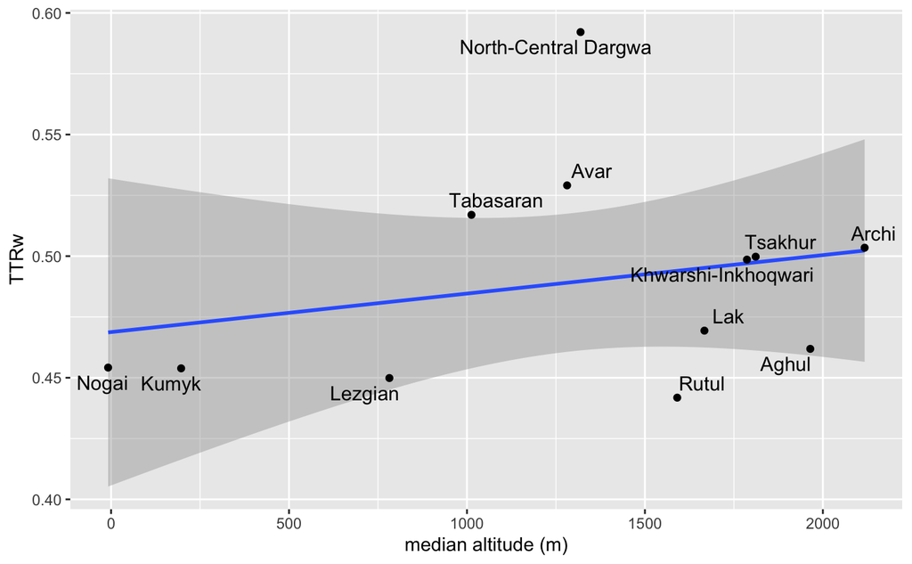

```r
full_dat2 %>%
  #distinct(elevation, value_median, .keep_all = TRUE) %>%
  distinct(alt_median, value, .keep_all = TRUE) %>%
  ggplot(aes(alt_median, value, label = lang))+
  geom_smooth(method=lm, se=TRUE) +
  geom_point()+
  ggrepel::geom_text_repel(size = 4)+
  labs(x = "median altitude (m)", y = "TTRw")
```

correlation coefficient

```r
res <- cor.test(full_dat2$alt_median, full_dat2$value,
                    method = "pearson")

res
```

```
    Pearson's product-moment correlation

data:  full_dat2$alt_median and full_dat2$value
t = 0.81016, df = 10, p-value = 0.4367
alternative hypothesis: true correlation is not equal to 0
95 percent confidence interval:
 -0.3798210  0.7195891
sample estimates:
      cor
0.2481786
```

```r
res <- lm(alt_median ~ value + aff, full_dat2)
summary(res)
```

```
Call:
lm(formula = alt_median ~ value + aff, data = full_dat2)

Residuals:
         1          2          3          4          5          6          7          8          9         10         11
 4.613e+02  5.091e+02  8.100e-13 -7.105e-14 -1.279e-13  1.030e+02 -4.263e-14 -6.910e+02 -1.030e+02  1.382e+02 -6.298e+02
        12
 2.122e+02

Coefficients:
            Estimate Std. Error t value Pr(>|t|)
(Intercept)   -54.79    4040.71  -0.014    0.990
value        2525.28    7569.83   0.334    0.752
affDargwa    -121.33     894.61  -0.136    0.897
affKipchak   -997.47     867.38  -1.150    0.302
affLak        536.69     881.47   0.609    0.569
affLezgic     391.69     691.37   0.567    0.596
affTsezic     582.43     791.17   0.736    0.495

Residual standard error: 535.1 on 5 degrees of freedom
Multiple R-squared:  0.7197,    Adjusted R-squared:  0.3833
F-statistic:  2.14 on 6 and 5 DF,  p-value: 0.2107
```

## TTR and weighted mean altitude

```r
weighted_alt_with_aff["lang"][weighted_alt_with_aff["lang"] == "Dargwa"] <- "North-Central Dargwa"
weighted_alt_with_aff["lang"][weighted_alt_with_aff["lang"] == "Xvarshi"] <- "Khwarshi-Inkhoqwari"
```

```r
merge(ttr2, weighted_alt_with_aff) -> full_dat1
full_dat1
```

| lang | iso_lang | value | weighted_altitude | aff |
| --- | --- | --- | --- | --- |
| Archi | aqc | 0.5034672 | 2137.5552 | Lezgic |
| Avar | ava | 0.5290907 | 766.5378 | Avar |
| Kumyk | kum | 0.4538658 | 349.7407 | Kipchak |
| Lak | lbe | 0.4693695 | 1681.9156 | Lak |
| Lezgian | lez | 0.4498751 | 538.6931 | Lezgic |
| North-Central Dargwa | dar | 0.5921301 | 1012.3251 | Dargwa |
| Rutul | rut | 0.4418199 | 1403.7060 | Lezgic |
| Tabasaran | tab | 0.5169807 | 810.8258 | Lezgic |
| Tsakhur | tkr | 0.4997710 | 1823.8479 | Lezgic |

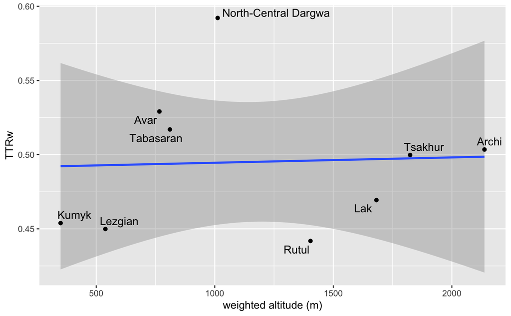

```r
full_dat1 %>%
  ggplot(aes(weighted_altitude, value, label = lang))+
  geom_smooth(method=lm, se=TRUE) +
  geom_point()+
  ggrepel::geom_text_repel(size = 4)+
  labs(x = "weighted altitude (m)", y = "TTRw")
```

```r
res <- cor.test(full_dat1$weighted_altitude, full_dat1$value,
                    method = "pearson")
res
```

```
    Pearson's product-moment correlation

data:  full_dat1$weighted_altitude and full_dat1$value
t = 0.12297, df = 7, p-value = 0.9056
alternative hypothesis: true correlation is not equal to 0
95 percent confidence interval:
 -0.6373459  0.6892957
sample estimates:
       cor
0.04642738
```

```r
res <- lm(weighted_altitude ~ value + aff, full_dat1)
summary(res)
```

```
Call:
lm(formula = weighted_altitude ~ value + aff, data = full_dat1)

Residuals:
         1          2          3          4          5          6          7          8          9
 6.567e+02 -2.558e-13  0.000e+00  0.000e+00 -5.916e+02 -5.684e-14  3.261e+02 -7.584e+02  3.672e+02

Coefficients:
            Estimate Std. Error t value Pr(>|t|)
(Intercept) -2693.77    5711.36  -0.472    0.669
value        6540.10   10706.19   0.611    0.584
affDargwa    -166.50    1233.12  -0.135    0.901
affKipchak     75.18    1309.08   0.057    0.958
affLak       1305.96    1214.04   1.076    0.361
affLezgic     881.86     942.93   0.935    0.419

Residual standard error: 729.8 on 3 degrees of freedom
Multiple R-squared:  0.4793,    Adjusted R-squared:  -0.3885
F-statistic: 0.5524 on 5 and 3 DF,  p-value: 0.738
```

# Distribution of correlation coefficients and p-values

When we extract TTR values at the particular corpus size, we take only one datapoint per language. However, how exact is this datapoint? We check this by sampling the original (not interpolated) data and looking at the variance of obtained TTR values. For folklore texts we calculated correlation coefficients for 100 samples of sentences with the total number of wordforms approximately equal to 1000.

the data in the file `TTR_100_datapoints_per_language_folk.txt` is produced by the python script `sampling_sentences_up_to_1000_tokens_folklore_texts`.

```r
ttr_samples <- read.csv("TTR_100_datapoints_per_language_folk.txt",
                header = TRUE, sep = ",")
ttr_samples <- tibble::rowid_to_column(ttr_samples, "sample")
ttr_long <- gather(ttr_samples, key = "key", value, -"sample")
ttr_long
```

| sample | key | value |
| --- | --- | --- |
| 1 | agx.folk | 0.6159136 |
| 2 | agx.folk | 0.6437126 |
| 3 | agx.folk | 0.6279762 |
| 4 | agx.folk | 0.6263627 |
| 5 | agx.folk | 0.6080000 |
| 6 | agx.folk | 0.6083916 |
| 7 | agx.folk | 0.5765408 |
| 8 | agx.folk | 0.5875371 |
| 9 | agx.folk | 0.5938124 |
| 10 | agx.folk | 0.6015857 |

[output cut: 990 more lines]

```r
ttr_long %>%
  separate(key, c('iso_lang', 'genre')) %>%
  select (-'genre') -> ttr3
ttr3["iso_lang"][ttr3["iso_lang"] == "arch"] <- "aqc"
ttr3["iso_lang"][ttr3["iso_lang"] == "lak"] <- "lbe"
ttr3["iso_lang"][ttr3["iso_lang"] == "and"] <- "ani"
ttr3 %>%
  mutate(lang = lang.iso(iso_lang)) -> ttr3
ttr3
```

| sample | iso_lang | value | lang |
| --- | --- | --- | --- |
| 1 | agx | 0.6159136 | Aghul |
| 2 | agx | 0.6437126 | Aghul |
| 3 | agx | 0.6279762 | Aghul |
| 4 | agx | 0.6263627 | Aghul |
| 5 | agx | 0.6080000 | Aghul |
| 6 | agx | 0.6083916 | Aghul |
| 7 | agx | 0.5765408 | Aghul |
| 8 | agx | 0.5875371 | Aghul |
| 9 | agx | 0.5938124 | Aghul |
| 10 | agx | 0.6015857 | Aghul |

[output cut: 990 more lines]

```r
merge(ttr3, weighted_alt_with_aff) -> full_dat3
full_dat3
```

| lang | sample | iso_lang | value | weighted_altitude | aff |
| --- | --- | --- | --- | --- | --- |
| Archi | 59 | aqc | 0.6613546 | 2137.5552 | Lezgic |
| Archi | 60 | aqc | 0.6646707 | 2137.5552 | Lezgic |
| Archi | 82 | aqc | 0.6129353 | 2137.5552 | Lezgic |
| Archi | 83 | aqc | 0.6626747 | 2137.5552 | Lezgic |
| Archi | 84 | aqc | 0.6427146 | 2137.5552 | Lezgic |
| Archi | 85 | aqc | 0.6473526 | 2137.5552 | Lezgic |
| Archi | 86 | aqc | 0.6500499 | 2137.5552 | Lezgic |
| Archi | 87 | aqc | 0.6869392 | 2137.5552 | Lezgic |
| Archi | 88 | aqc | 0.6590229 | 2137.5552 | Lezgic |
| Archi | 89 | aqc | 0.6613704 | 2137.5552 | Lezgic |

[output cut: 890 more lines]

calculate correlation coefficients for each sample and save results in vector

```r
correlation_coefficients_folk <- c()
for (sample_number in 1:100){ #the number of samples - change if needed
  filter (full_dat3, sample == sample_number) -> full_dat4
  res <- cor.test(full_dat4$weighted_altitude, full_dat4$value,
                    method = "pearson")
  correlation_coefficients_folk <- append(correlation_coefficients_folk, as.numeric(res$estimate))
}
correlation_coefficients_folk
```

```
  [1]  0.240821205 -0.233748238 -0.049008255 -0.169439230 -0.133116129 -0.180783611 -0.118526204 -0.031921436  0.129114441
 [10] -0.034360529 -0.040806220 -0.069791927 -0.216138313 -0.234043927 -0.169955090 -0.155893058 -0.272511973 -0.217647945
 [19] -0.160224168  0.088897750 -0.169667206 -0.106195882 -0.245144406 -0.243245890  0.077322913 -0.436911000 -0.140313524
 [28] -0.089689045 -0.170682551 -0.105964096 -0.116955736 -0.533939470 -0.220321170 -0.228502618 -0.224640571 -0.173885425
 [37] -0.204911126  0.022563220  0.378433608 -0.295729183 -0.297991939 -0.237944959 -0.044787153 -0.200567514 -0.053652014
 [46] -0.417782326 -0.631335176 -0.195180683 -0.136546106  0.159424615 -0.263386601 -0.259285533 -0.323429030 -0.017547185
 [55] -0.019812774 -0.218029680 -0.194056617 -0.353452260 -0.094402133 -0.056134652 -0.141316404  0.052182956 -0.001620403
 [64] -0.170044348 -0.376122857 -0.028745129 -0.340733574 -0.153134387 -0.099784116 -0.267174842  0.015099845 -0.077143928
 [73] -0.103929538 -0.356216554 -0.289765523 -0.266447161 -0.017721441 -0.121352894  0.060478767 -0.041650655 -0.376081207
 [82] -0.503309321 -0.150062491 -0.175903457 -0.183199911 -0.292887129 -0.130251746 -0.040911370 -0.068223576 -0.110164974
 [91] -0.205670608 -0.217902583 -0.538859800 -0.169679134 -0.080488239 -0.370954809 -0.035180768 -0.168065868 -0.308083235
[100]  0.041378199
```

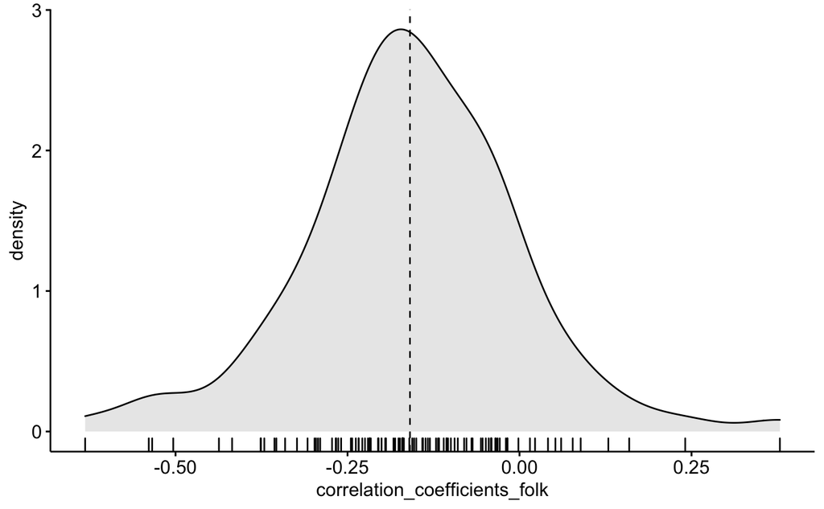

```r
ggdensity(data.frame(correlation_coefficients_folk),
          x = "correlation_coefficients_folk",
          fill = "lightgray",
          add = "mean",
          rug = TRUE)
```

calculate p-values of correlation coefficients for each sample and save results in vector

```r
p.values <- c()
for (sample_number in 1:100){ #the number of samples - change if needed
  filter (full_dat3, sample == sample_number) -> full_dat4
  res <- cor.test(full_dat4$weighted_altitude, full_dat4$value,
                    method = "pearson")
  p.values <- append(p.values, as.numeric(res$p.value))
}
p.values
```

```
  [1] 0.53249867 0.54496412 0.90036082 0.66297321 0.73279062 0.64159428 0.76134934 0.93502538 0.74059690 0.93007014 0.91698552
 [12] 0.85839691 0.57646963 0.54444079 0.66199634 0.68877889 0.47806151 0.57374326 0.68049644 0.82008743 0.66254144 0.78568238
 [23] 0.52493450 0.52825107 0.84326177 0.23963985 0.71880391 0.81850735 0.66061952 0.78614140 0.76443894 0.13869265 0.56892700
 [34] 0.55427990 0.56117640 0.65456814 0.59689036 0.95405408 0.31524093 0.43974241 0.43608221 0.53755440 0.90891274 0.60485762
 [45] 0.89096286 0.26317704 0.06822162 0.61478868 0.72611639 0.68202324 0.49349208 0.50049243 0.39588235 0.96426234 0.95965095
 [56] 0.57305459 0.61686789 0.35076423 0.80910805 0.88594329 0.71686064 0.89393469 0.99669895 0.66182736 0.31844773 0.94148121
 [67] 0.36956107 0.69406935 0.79840060 0.48706169 0.96924469 0.84362098 0.79017298 0.34674162 0.44945334 0.48829420 0.96390762
 [78] 0.75579573 0.87716859 0.91527255 0.31850568 0.16720463 0.69997397 0.65076424 0.63706937 0.44435871 0.73837619 0.91677220
 [89] 0.86155402 0.77783114 0.59550105 0.57328385 0.13440080 0.66251886 0.83691334 0.32567864 0.92840421 0.66557605 0.41992428
[100] 0.91582521
```

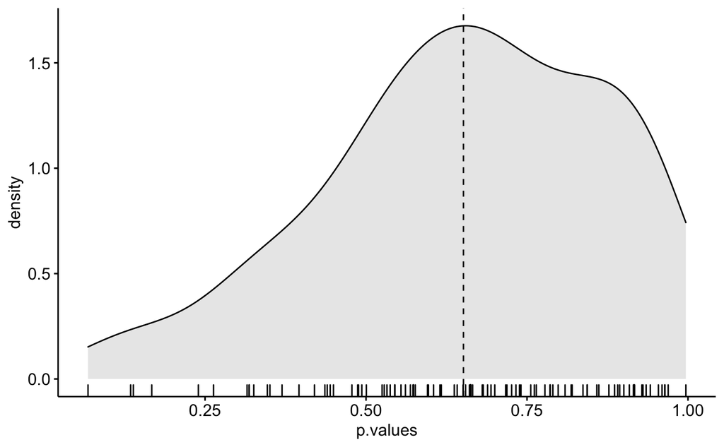

```r
ggdensity(data.frame(p.values),
          x = "p.values",
          fill = "lightgray",
          add = "mean",
          rug = TRUE)
```

# Checking correlations in extrapolated data

## Extrapolation of Heap’s curves with zipfR

```r
languages = c('agx', 'ava', 'kum', 'rut', 'dar', 'tab', 'lak', 'lez','nog', 'tkr', 'arch', 'khv')

#for checking correlations at different corpus sizes
corpus_sizes <- sort(sample(1:45000, size = 100, replace = TRUE))
```

```r
ttr_at_different_corpus_sizes <- data.frame(corpus_sizes)
for (language in languages) {
  freq_list <- read.tfl(paste0("frequency_lists_texts/", language, "-folk_freq.txt"))
  freq_spectrum <- tfl2spc(freq_list)


  type_count <- read.vgc(paste0("type_counts_texts/", language, "-folk_type_counts.txt"))
  var_name1 <- paste0("type_count_", language)
  assign(var_name1, type_count)

  extrapolated_model <- lnre("fzm", freq_spectrum, exact=FALSE)


  extrapolated_type_count <- lnre.vgc(extrapolated_model, (1:45000), variances=FALSE)

  #for checking correlations at different corpus sizes
  ttr_for_one_language <- c()
  for (x in 1:100){
    n_of_types <- extrapolated_type_count$V[extrapolated_type_count$N == corpus_sizes[x]]
    ttr_for_one_language <- append(ttr_for_one_language, n_of_types/corpus_sizes[x])
    }
  ttr_at_different_corpus_sizes[ , ncol(ttr_at_different_corpus_sizes) + 1] <- ttr_for_one_language      # Append new column
  colnames(ttr_at_different_corpus_sizes)[ncol(ttr_at_different_corpus_sizes)] <- language


  var_name2 <- paste0("extrapolated_type_count_", language)
  assign(var_name2, extrapolated_type_count)
}
write.csv(ttr_at_different_corpus_sizes,"ttr_at_different_corpus_sizes.csv", row.names = FALSE)
```

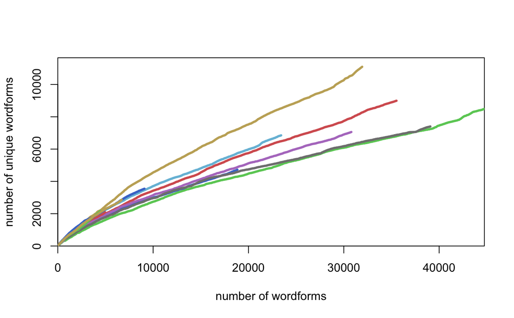

```r
plot(type_count_agx,
     type_count_ava,
     type_count_kum,
     type_count_rut,
     type_count_dar,
     type_count_tab,
     type_count_lak,
     type_count_lez,
     type_count_nog,
     type_count_tkr,
 #    type_count_tat,
     type_count_arch,
     type_count_khv,
     xlab = "number of wordforms", ylab = "number of unique wordforms", main = ""

     # legend=c("observed aghul",
     #          "observed avar",
     #          "observed kumyk",
     #          "observed rutul",
     #          "observed dargwa",
     #          "observed tabasaran",
     #          "observed lak",
     #          "observed lezgian",
     #          "observed nogai",
     #          "observed tsakhur",
     #          "observed tat",
     #          "observed archi",
     #          "observed khwarshi")
     )
```

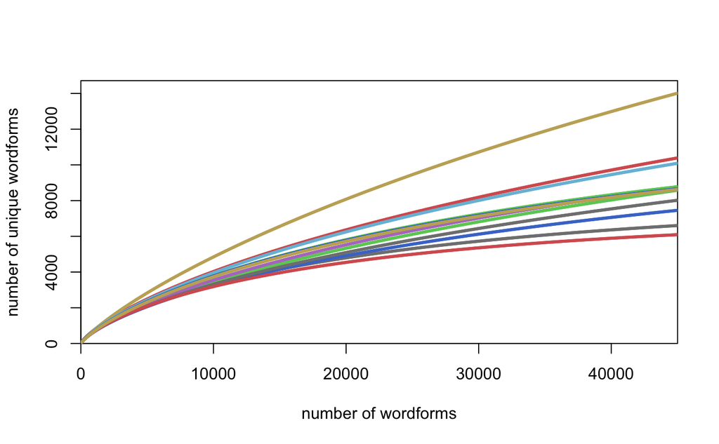

```r
plot(extrapolated_type_count_agx,
     extrapolated_type_count_ava,
     extrapolated_type_count_kum,
     extrapolated_type_count_rut,
     extrapolated_type_count_dar,
     extrapolated_type_count_tab,
     extrapolated_type_count_lak,
     extrapolated_type_count_lez,
     extrapolated_type_count_nog,
     extrapolated_type_count_tkr,
    # extrapolated_type_count_tat,
     extrapolated_type_count_arch,
     extrapolated_type_count_khv,
     xlab = "number of wordforms", ylab = "number of unique wordforms", main = ""

     )
```

## Merging two datasets (extrapolated TTR and median altitude)

```r
ttr_at_different_corpus_sizes <- read.csv("ttr_at_different_corpus_sizes.csv",
                header = TRUE)

ttr_at_different_corpus_sizes <- tibble::rowid_to_column(ttr_at_different_corpus_sizes, "sample")
ttr_at_different_corpus_sizes
```

| sample | corpus_sizes | agx | ava | kum | rut | dar | tab | lak | lez | nog | tkr | arch | khv |
| --- | --- | --- | --- | --- | --- | --- | --- | --- | --- | --- | --- | --- | --- |
| 1 | 1126 | 0.6461777 | 0.7395949 | 0.6448549 | 0.6328648 | 0.7420612 | 0.7060052 | 0.6537023 | 0.6561623 | 0.6396592 | 0.6718066 | 0.6746399 | 0.6632743 |
| 2 | 1417 | 0.6121683 | 0.6985960 | 0.6073780 | 0.5958238 | 0.7148538 | 0.6698561 | 0.6183450 | 0.6150534 | 0.6048833 | 0.6405408 | 0.6429467 | 0.6323279 |
| 3 | 1852 | 0.5726874 | 0.6526306 | 0.5655172 | 0.5541170 | 0.6831809 | 0.6288386 | 0.5783810 | 0.5694440 | 0.5645332 | 0.6041919 | 0.6061040 | 0.5963512 |
| 4 | 2429 | 0.5328741 | 0.6079525 | 0.5249925 | 0.5133958 | 0.6511160 | 0.5884510 | 0.5391961 | 0.5256120 | 0.5238725 | 0.5674620 | 0.5688798 | 0.5599986 |
| 5 | 2478 | 0.5299509 | 0.6047355 | 0.5220810 | 0.5104567 | 0.6487558 | 0.5855225 | 0.5363613 | 0.5224754 | 0.5208885 | 0.5647616 | 0.5661433 | 0.5573260 |
| 6 | 3007 | 0.5017026 | 0.5740758 | 0.4943767 | 0.4823997 | 0.6258978 | 0.5574711 | 0.5092529 | 0.4927150 | 0.4920639 | 0.5386371 | 0.5396711 | 0.5314709 |
| 7 | 3503 | 0.4795165 | 0.5505210 | 0.4731478 | 0.4607881 | 0.6078735 | 0.5357429 | 0.4883126 | 0.4700178 | 0.4694416 | 0.5180763 | 0.5188392 | 0.5111227 |
| 8 | 3575 | 0.4765678 | 0.5474239 | 0.4703601 | 0.4579429 | 0.6054725 | 0.5328742 | 0.4855518 | 0.4670444 | 0.4664361 | 0.5153404 | 0.5160674 | 0.5084152 |
| 9 | 3640 | 0.4739579 | 0.5446891 | 0.4678993 | 0.4554299 | 0.6033463 | 0.5303390 | 0.4831125 | 0.4644210 | 0.4637763 | 0.5129182 | 0.5136135 | 0.5060181 |
| 10 | 4086 | 0.4572544 | 0.5273268 | 0.4522920 | 0.4394607 | 0.5897119 | 0.5141927 | 0.4675944 | 0.4478123 | 0.4467591 | 0.4974003 | 0.4978933 | 0.4906612 |

[output cut: 90 more lines]

```r
ttr_at_different_corpus_sizes %>%
  select (-"corpus_sizes") %>%
  gather(key = "iso_lang", value, -"sample") -> ttr_at_different_corpus_sizes_long
ttr_at_different_corpus_sizes_long["iso_lang"][ttr_at_different_corpus_sizes_long["iso_lang"] == "arch"] <- "aqc"
ttr_at_different_corpus_sizes_long["iso_lang"][ttr_at_different_corpus_sizes_long["iso_lang"] == "lak"] <- "lbe"
ttr_at_different_corpus_sizes_long["iso_lang"][ttr_at_different_corpus_sizes_long["iso_lang"] == "and"] <- "ani"
ttr_at_different_corpus_sizes_long["iso_lang"][ttr_at_different_corpus_sizes_long["iso_lang"] == "tat"] <- "ttt"
ttr_at_different_corpus_sizes_long
```

| sample | iso_lang | value |
| --- | --- | --- |
| 1 | agx | 0.6461777 |
| 2 | agx | 0.6121683 |
| 3 | agx | 0.5726874 |
| 4 | agx | 0.5328741 |
| 5 | agx | 0.5299509 |
| 6 | agx | 0.5017026 |
| 7 | agx | 0.4795165 |
| 8 | agx | 0.4765678 |
| 9 | agx | 0.4739579 |
| 10 | agx | 0.4572544 |

[output cut: 990 more lines]

```r
merge(ttr_at_different_corpus_sizes_long, altitude_medians2_with_aff) -> full_dat_folk
full_dat_folk
```

| iso_lang | sample | value | gltc_lang | alt_median | n_villages | aff |
| --- | --- | --- | --- | --- | --- | --- |
| agx | 1 | 0.6461777 | aghu1253 | 1964.591187 | 21 | Lezgic |
| agx | 2 | 0.6121683 | aghu1253 | 1964.591187 | 21 | Lezgic |
| agx | 3 | 0.5726874 | aghu1253 | 1964.591187 | 21 | Lezgic |
| agx | 4 | 0.5328741 | aghu1253 | 1964.591187 | 21 | Lezgic |
| agx | 5 | 0.5299509 | aghu1253 | 1964.591187 | 21 | Lezgic |
| agx | 6 | 0.5017026 | aghu1253 | 1964.591187 | 21 | Lezgic |
| agx | 7 | 0.4795165 | aghu1253 | 1964.591187 | 21 | Lezgic |
| agx | 8 | 0.4765678 | aghu1253 | 1964.591187 | 21 | Lezgic |
| agx | 9 | 0.4739579 | aghu1253 | 1964.591187 | 21 | Lezgic |
| agx | 10 | 0.4572544 | aghu1253 | 1964.591187 | 21 | Lezgic |

[output cut: 990 more lines]

```r
full_dat_folk %>%
  mutate(lang = lang.iso(iso_lang)) -> full_dat_folk2
full_dat_folk2
```

| iso_lang | sample | value | gltc_lang | alt_median | n_villages | aff | lang |
| --- | --- | --- | --- | --- | --- | --- | --- |
| agx | 1 | 0.6461777 | aghu1253 | 1964.591187 | 21 | Lezgic | Aghul |
| agx | 2 | 0.6121683 | aghu1253 | 1964.591187 | 21 | Lezgic | Aghul |
| agx | 3 | 0.5726874 | aghu1253 | 1964.591187 | 21 | Lezgic | Aghul |
| agx | 4 | 0.5328741 | aghu1253 | 1964.591187 | 21 | Lezgic | Aghul |
| agx | 5 | 0.5299509 | aghu1253 | 1964.591187 | 21 | Lezgic | Aghul |
| agx | 6 | 0.5017026 | aghu1253 | 1964.591187 | 21 | Lezgic | Aghul |
| agx | 7 | 0.4795165 | aghu1253 | 1964.591187 | 21 | Lezgic | Aghul |
| agx | 8 | 0.4765678 | aghu1253 | 1964.591187 | 21 | Lezgic | Aghul |
| agx | 9 | 0.4739579 | aghu1253 | 1964.591187 | 21 | Lezgic | Aghul |
| agx | 10 | 0.4572544 | aghu1253 | 1964.591187 | 21 | Lezgic | Aghul |

[output cut: 990 more lines]

## Checking correlations at different corpus sizes

choose a sample (a particular corpus size) where you want to check the correlation it can be seen the results for differnt samples are completely different

```r
full_dat_folk2 %>%
  filter(sample == "100") -> full_dat_folk3
```

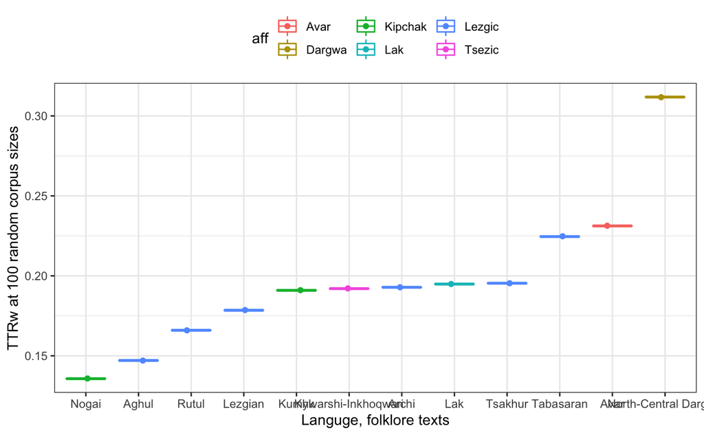

```r
#full_dat_folk2  %>%
full_dat_folk3  %>%
  ggplot(aes(reorder(lang, value, FUN = median), value, color = aff))+
  geom_boxplot(outlier.shape = NA)+
  geom_jitter(width = 0.1)+
  labs(x = "Languge, folklore texts",
       y = "TTRw at 100 random corpus sizes")+
  theme_bw()+
  theme(legend.position = "top")
```

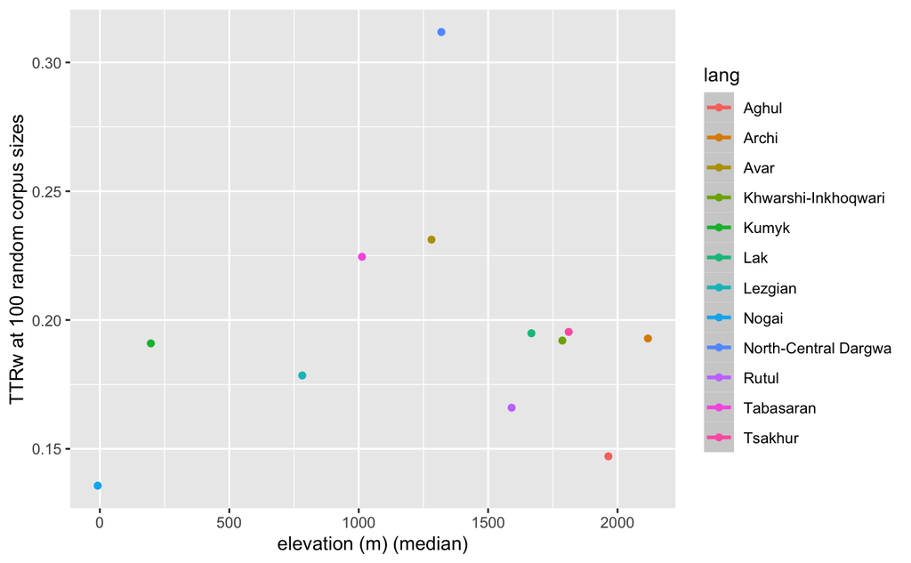

```r
full_dat_folk3 %>%
#full_dat_folk2 %>%
  ggplot(aes(alt_median, value, label = lang, col = lang))+
  geom_smooth(method=lm) +
  geom_point()+
  labs(x = "elevation (m) (median)", y = "TTRw at 100 random corpus sizes")
```

```r
res <- cor.test(full_dat_folk3$alt_median, full_dat_folk3$value,
                    method = "pearson")

res
```

```
    Pearson's product-moment correlation

data:  full_dat_folk3$alt_median and full_dat_folk3$value
t = 0.37823, df = 10, p-value = 0.7132
alternative hypothesis: true correlation is not equal to 0
95 percent confidence interval:
 -0.4884316  0.6484644
sample estimates:
      cor
0.1187597
```